# Google Data Analytics Capstone

Huma Perveen

1/3/2022

## Case Study: How Does a Bike-Share Navigate Speedy Success?

### Scenario

I am a junior data analyst working in the marketing analyst team at Cyclistic, a bike-share company in Chicago. The director of marketing believes the company’s future success depends on maximizing the number of annual memberships. Therefore, my team wants to understand how casual riders and annual members use Cyclistic bikes differently. From these insights, my team will design a new marketing strategy to convert casual riders into annual members.

### About the company

In 2016, Cyclistic launched a successful bike-share offering. Since then, the program has grown to a fleet of 5,824 bicycles that are geotracked and locked into a network of 692 stations across Chicago. The bikes can be unlocked from one station and returned to any other station in the system anytime.

### Ask

#### Guiding questions:

How do annual members and casual riders use Cyclistic bikes differently?

#### Business tasks:

Design marketing strategies aimed at converting casual riders into annual members.

#### Key stakeholders:

- **Lily Moreno:** The director of marketing and your manager. Moreno is responsible for the development of campaigns and initiatives to promote the bike-share program. These may include email, social media, and other channels.
- **Cyclistic marketing analytics team:** A team of data analysts who are responsible for collecting, analyzing, and reporting data that helps guide Cyclistic marketing strategy.

##### I will produce a report with the following deliverables:

1. A clear statement of the business task
2. A description of all data sources used
3. Documentation of any cleaning or manipulation of data
4. A summary of analysis
5. Supporting visualizations and key findings
6. Top three recommendations based on your analysis

### Prepare

I will use Cyclistic’s historical trip data from Dec2020- Nov2021 to analyze and identify trends.For the purposes of this case study, [Download the previous 12 months of Cyclistic trip data here.](https://divvy-tripdata.s3.amazonaws.com/index.html) the datasets are appropriate and will enable me to answer the business questions. The data has been made available by Motivate International Inc. under this [license.](https://ride.divvybikes.com/data-license-agreement)

- This is public data that I will use to explore how different customer types are using Cyclistic bikes.
- Data is example of ROCCC because it is original data from a reliable organization, comprehensive, current, and cited.
- I downloaded and stored data appropriately. I follow the file naming convention appropriately too.

#### Step 1: Install and Load required packages

```r
# for data manipulation, exploration, and visualization.
library(tidyverse)
# for date functions
library(lubridate)
library(scales)
```

#### Step 2: Import Data

12 months trip data from Dec,2020 to Nov,2021

```r
tripdata_2020_12 <- read_csv("../source/202012-divvy-tripdata.csv")
tripdata_2021_01 <- read_csv("../source/202101-divvy-tripdata.csv")
tripdata_2021_02 <- read_csv("../source/202102-divvy-tripdata.csv")
tripdata_2021_03 <- read_csv("../source/202103-divvy-tripdata.csv")
tripdata_2021_04 <- read_csv("../source/202104-divvy-tripdata.csv")
tripdata_2021_05 <- read_csv("../source/202105-divvy-tripdata.csv")
tripdata_2021_06 <- read_csv("../source/202106-divvy-tripdata.csv")
tripdata_2021_07 <- read_csv("../source/202107-divvy-tripdata.csv")
tripdata_2021_08 <- read_csv("../source/202108-divvy-tripdata.csv")
tripdata_2021_09 <- read_csv("../source/202109-divvy-tripdata.csv")
tripdata_2021_10 <- read_csv("../source/202110-divvy-tripdata.csv")
tripdata_2021_11 <- read_csv("../source/202111-divvy-tripdata.csv")
```

Check column name should be consistent

```r
colnames(tripdata_2020_12)
```

```
##  [1] "ride_id"            "rideable_type"      "started_at"
##  [4] "ended_at"           "start_station_name" "start_station_id"
##  [7] "end_station_name"   "end_station_id"     "start_lat"
## [10] "start_lng"          "end_lat"            "end_lng"
## [13] "member_casual"
```

```r
colnames(tripdata_2021_01)
```

```
##  [1] "ride_id"            "rideable_type"      "started_at"
##  [4] "ended_at"           "start_station_name" "start_station_id"
##  [7] "end_station_name"   "end_station_id"     "start_lat"
## [10] "start_lng"          "end_lat"            "end_lng"
## [13] "member_casual"
```

```r
colnames(tripdata_2021_02)
```

```
##  [1] "ride_id"            "rideable_type"      "started_at"
##  [4] "ended_at"           "start_station_name" "start_station_id"
##  [7] "end_station_name"   "end_station_id"     "start_lat"
## [10] "start_lng"          "end_lat"            "end_lng"
## [13] "member_casual"
```

```r
colnames(tripdata_2021_03)
```

```
##  [1] "ride_id"            "rideable_type"      "started_at"
##  [4] "ended_at"           "start_station_name" "start_station_id"
##  [7] "end_station_name"   "end_station_id"     "start_lat"
## [10] "start_lng"          "end_lat"            "end_lng"
## [13] "member_casual"
```

```r
colnames(tripdata_2021_04)
```

```
##  [1] "ride_id"            "rideable_type"      "started_at"
##  [4] "ended_at"           "start_station_name" "start_station_id"
##  [7] "end_station_name"   "end_station_id"     "start_lat"
## [10] "start_lng"          "end_lat"            "end_lng"
## [13] "member_casual"
```

```r
colnames(tripdata_2021_05)
```

```
##  [1] "ride_id"            "rideable_type"      "started_at"
##  [4] "ended_at"           "start_station_name" "start_station_id"
##  [7] "end_station_name"   "end_station_id"     "start_lat"
## [10] "start_lng"          "end_lat"            "end_lng"
## [13] "member_casual"
```

```r
colnames(tripdata_2021_06)
```

```
##  [1] "ride_id"            "rideable_type"      "started_at"
##  [4] "ended_at"           "start_station_name" "start_station_id"
##  [7] "end_station_name"   "end_station_id"     "start_lat"
## [10] "start_lng"          "end_lat"            "end_lng"
## [13] "member_casual"
```

```r
colnames(tripdata_2021_07)
```

```
##  [1] "ride_id"            "rideable_type"      "started_at"
##  [4] "ended_at"           "start_station_name" "start_station_id"
##  [7] "end_station_name"   "end_station_id"     "start_lat"
## [10] "start_lng"          "end_lat"            "end_lng"
## [13] "member_casual"
```

```r
colnames(tripdata_2021_08)
```

```
##  [1] "ride_id"            "rideable_type"      "started_at"
##  [4] "ended_at"           "start_station_name" "start_station_id"
##  [7] "end_station_name"   "end_station_id"     "start_lat"
## [10] "start_lng"          "end_lat"            "end_lng"
## [13] "member_casual"
```

```r
colnames(tripdata_2021_09)
```

```
##  [1] "ride_id"            "rideable_type"      "started_at"
##  [4] "ended_at"           "start_station_name" "start_station_id"
##  [7] "end_station_name"   "end_station_id"     "start_lat"
## [10] "start_lng"          "end_lat"            "end_lng"
## [13] "member_casual"
```

```r
colnames(tripdata_2021_10)
```

```
##  [1] "ride_id"            "rideable_type"      "started_at"
##  [4] "ended_at"           "start_station_name" "start_station_id"
##  [7] "end_station_name"   "end_station_id"     "start_lat"
## [10] "start_lng"          "end_lat"            "end_lng"
## [13] "member_casual"
```

```r
colnames(tripdata_2021_11)
```

```
##  [1] "ride_id"            "rideable_type"      "started_at"
##  [4] "ended_at"           "start_station_name" "start_station_id"
##  [7] "end_station_name"   "end_station_id"     "start_lat"
## [10] "start_lng"          "end_lat"            "end_lng"
## [13] "member_casual"
```

Check the structure of dataframes for any incongruencies

```r
str(tripdata_2020_12)
```

```
## spec_tbl_df [131,573 × 13] (S3: spec_tbl_df/tbl_df/tbl/data.frame)
##  $ ride_id           : chr [1:131573] "70B6A9A437D4C30D" "158A465D4E74C54A" "5262016E0F1F2F9A" "BE119628E44F871E" ...
##  $ rideable_type     : chr [1:131573] "classic_bike" "electric_bike" "electric_bike" "electric_bike" ...
##  $ started_at        : POSIXct[1:131573], format: "2020-12-27 12:44:29" "2020-12-18 17:37:15" ...
##  $ ended_at          : POSIXct[1:131573], format: "2020-12-27 12:55:06" "2020-12-18 17:44:19" ...
##  $ start_station_name: chr [1:131573] "Aberdeen St & Jackson Blvd" NA NA NA ...
##  $ start_station_id  : chr [1:131573] "13157" NA NA NA ...
##  $ end_station_name  : chr [1:131573] "Desplaines St & Kinzie St" NA NA NA ...
##  $ end_station_id    : chr [1:131573] "TA1306000003" NA NA NA ...
##  $ start_lat         : num [1:131573] 41.9 41.9 41.9 41.9 41.8 ...
##  $ start_lng         : num [1:131573] -87.7 -87.7 -87.7 -87.7 -87.6 ...
##  $ end_lat           : num [1:131573] 41.9 41.9 41.9 41.9 41.8 ...
##  $ end_lng           : num [1:131573] -87.6 -87.7 -87.7 -87.7 -87.6 ...
##  $ member_casual     : chr [1:131573] "member" "member" "member" "member" ...
##  - attr(*, "spec")=
##   .. cols(
##   ..   ride_id = col_character(),
##   ..   rideable_type = col_character(),
##   ..   started_at = col_datetime(format = ""),
##   ..   ended_at = col_datetime(format = ""),
##   ..   start_station_name = col_character(),
##   ..   start_station_id = col_character(),
##   ..   end_station_name = col_character(),
##   ..   end_station_id = col_character(),
##   ..   start_lat = col_double(),
##   ..   start_lng = col_double(),
##   ..   end_lat = col_double(),
##   ..   end_lng = col_double(),
##   ..   member_casual = col_character()
##   .. )
##  - attr(*, "problems")=<externalptr>
```

```r
str(tripdata_2021_01)
```

```
## spec_tbl_df [96,834 × 13] (S3: spec_tbl_df/tbl_df/tbl/data.frame)
##  $ ride_id           : chr [1:96834] "E19E6F1B8D4C42ED" "DC88F20C2C55F27F" "EC45C94683FE3F27" "4FA453A75AE377DB" ...
##  $ rideable_type     : chr [1:96834] "electric_bike" "electric_bike" "electric_bike" "electric_bike" ...
##  $ started_at        : POSIXct[1:96834], format: "2021-01-23 16:14:19" "2021-01-27 18:43:08" ...
##  $ ended_at          : POSIXct[1:96834], format: "2021-01-23 16:24:44" "2021-01-27 18:47:12" ...
##  $ start_station_name: chr [1:96834] "California Ave & Cortez St" "California Ave & Cortez St" "California Ave & Cortez St" "California Ave & Cortez St" ...
##  $ start_station_id  : chr [1:96834] "17660" "17660" "17660" "17660" ...
##  $ end_station_name  : chr [1:96834] NA NA NA NA ...
##  $ end_station_id    : chr [1:96834] NA NA NA NA ...
##  $ start_lat         : num [1:96834] 41.9 41.9 41.9 41.9 41.9 ...
##  $ start_lng         : num [1:96834] -87.7 -87.7 -87.7 -87.7 -87.7 ...
##  $ end_lat           : num [1:96834] 41.9 41.9 41.9 41.9 41.9 ...
##  $ end_lng           : num [1:96834] -87.7 -87.7 -87.7 -87.7 -87.7 ...
##  $ member_casual     : chr [1:96834] "member" "member" "member" "member" ...
##  - attr(*, "spec")=
##   .. cols(
##   ..   ride_id = col_character(),
##   ..   rideable_type = col_character(),
##   ..   started_at = col_datetime(format = ""),
##   ..   ended_at = col_datetime(format = ""),
##   ..   start_station_name = col_character(),
##   ..   start_station_id = col_character(),
##   ..   end_station_name = col_character(),
##   ..   end_station_id = col_character(),
##   ..   start_lat = col_double(),
##   ..   start_lng = col_double(),
##   ..   end_lat = col_double(),
##   ..   end_lng = col_double(),
##   ..   member_casual = col_character()
##   .. )
##  - attr(*, "problems")=<externalptr>
```

```r
str(tripdata_2021_02)
```

```
## spec_tbl_df [49,622 × 13] (S3: spec_tbl_df/tbl_df/tbl/data.frame)
##  $ ride_id           : chr [1:49622] "89E7AA6C29227EFF" "0FEFDE2603568365" "E6159D746B2DBB91" "B32D3199F1C2E75B" ...
##  $ rideable_type     : chr [1:49622] "classic_bike" "classic_bike" "electric_bike" "classic_bike" ...
##  $ started_at        : POSIXct[1:49622], format: "2021-02-12 16:14:56" "2021-02-14 17:52:38" ...
##  $ ended_at          : POSIXct[1:49622], format: "2021-02-12 16:21:43" "2021-02-14 18:12:09" ...
##  $ start_station_name: chr [1:49622] "Glenwood Ave & Touhy Ave" "Glenwood Ave & Touhy Ave" "Clark St & Lake St" "Wood St & Chicago Ave" ...
##  $ start_station_id  : chr [1:49622] "525" "525" "KA1503000012" "637" ...
##  $ end_station_name  : chr [1:49622] "Sheridan Rd & Columbia Ave" "Bosworth Ave & Howard St" "State St & Randolph St" "Honore St & Division St" ...
##  $ end_station_id    : chr [1:49622] "660" "16806" "TA1305000029" "TA1305000034" ...
##  $ start_lat         : num [1:49622] 42 42 41.9 41.9 41.8 ...
##  $ start_lng         : num [1:49622] -87.7 -87.7 -87.6 -87.7 -87.6 ...
##  $ end_lat           : num [1:49622] 42 42 41.9 41.9 41.8 ...
##  $ end_lng           : num [1:49622] -87.7 -87.7 -87.6 -87.7 -87.6 ...
##  $ member_casual     : chr [1:49622] "member" "casual" "member" "member" ...
##  - attr(*, "spec")=
##   .. cols(
##   ..   ride_id = col_character(),
##   ..   rideable_type = col_character(),
##   ..   started_at = col_datetime(format = ""),
##   ..   ended_at = col_datetime(format = ""),
##   ..   start_station_name = col_character(),
##   ..   start_station_id = col_character(),
##   ..   end_station_name = col_character(),
##   ..   end_station_id = col_character(),
##   ..   start_lat = col_double(),
##   ..   start_lng = col_double(),
##   ..   end_lat = col_double(),
##   ..   end_lng = col_double(),
##   ..   member_casual = col_character()
##   .. )
##  - attr(*, "problems")=<externalptr>
```

```r
str(tripdata_2021_03)
```

```
## spec_tbl_df [228,496 × 13] (S3: spec_tbl_df/tbl_df/tbl/data.frame)
##  $ ride_id           : chr [1:228496] "CFA86D4455AA1030" "30D9DC61227D1AF3" "846D87A15682A284" "994D05AA75A168F2" ...
##  $ rideable_type     : chr [1:228496] "classic_bike" "classic_bike" "classic_bike" "classic_bike" ...
##  $ started_at        : POSIXct[1:228496], format: "2021-03-16 08:32:30" "2021-03-28 01:26:28" ...
##  $ ended_at          : POSIXct[1:228496], format: "2021-03-16 08:36:34" "2021-03-28 01:36:55" ...
##  $ start_station_name: chr [1:228496] "Humboldt Blvd & Armitage Ave" "Humboldt Blvd & Armitage Ave" "Shields Ave & 28th Pl" "Winthrop Ave & Lawrence Ave" ...
##  $ start_station_id  : chr [1:228496] "15651" "15651" "15443" "TA1308000021" ...
##  $ end_station_name  : chr [1:228496] "Stave St & Armitage Ave" "Central Park Ave & Bloomingdale Ave" "Halsted St & 35th St" "Broadway & Sheridan Rd" ...
##  $ end_station_id    : chr [1:228496] "13266" "18017" "TA1308000043" "13323" ...
##  $ start_lat         : num [1:228496] 41.9 41.9 41.8 42 42 ...
##  $ start_lng         : num [1:228496] -87.7 -87.7 -87.6 -87.7 -87.7 ...
##  $ end_lat           : num [1:228496] 41.9 41.9 41.8 42 42.1 ...
##  $ end_lng           : num [1:228496] -87.7 -87.7 -87.6 -87.6 -87.7 ...
##  $ member_casual     : chr [1:228496] "casual" "casual" "casual" "casual" ...
##  - attr(*, "spec")=
##   .. cols(
##   ..   ride_id = col_character(),
##   ..   rideable_type = col_character(),
##   ..   started_at = col_datetime(format = ""),
##   ..   ended_at = col_datetime(format = ""),
##   ..   start_station_name = col_character(),
##   ..   start_station_id = col_character(),
##   ..   end_station_name = col_character(),
##   ..   end_station_id = col_character(),
##   ..   start_lat = col_double(),
##   ..   start_lng = col_double(),
##   ..   end_lat = col_double(),
##   ..   end_lng = col_double(),
##   ..   member_casual = col_character()
##   .. )
##  - attr(*, "problems")=<externalptr>
```

```r
str(tripdata_2021_04)
```

```
## spec_tbl_df [337,230 × 13] (S3: spec_tbl_df/tbl_df/tbl/data.frame)
##  $ ride_id           : chr [1:337230] "6C992BD37A98A63F" "1E0145613A209000" "E498E15508A80BAD" "1887262AD101C604" ...
##  $ rideable_type     : chr [1:337230] "classic_bike" "docked_bike" "docked_bike" "classic_bike" ...
##  $ started_at        : POSIXct[1:337230], format: "2021-04-12 18:25:36" "2021-04-27 17:27:11" ...
##  $ ended_at          : POSIXct[1:337230], format: "2021-04-12 18:56:55" "2021-04-27 18:31:29" ...
##  $ start_station_name: chr [1:337230] "State St & Pearson St" "Dorchester Ave & 49th St" "Loomis Blvd & 84th St" "Honore St & Division St" ...
##  $ start_station_id  : chr [1:337230] "TA1307000061" "KA1503000069" "20121" "TA1305000034" ...
##  $ end_station_name  : chr [1:337230] "Southport Ave & Waveland Ave" "Dorchester Ave & 49th St" "Loomis Blvd & 84th St" "Southport Ave & Waveland Ave" ...
##  $ end_station_id    : chr [1:337230] "13235" "KA1503000069" "20121" "13235" ...
##  $ start_lat         : num [1:337230] 41.9 41.8 41.7 41.9 41.7 ...
##  $ start_lng         : num [1:337230] -87.6 -87.6 -87.7 -87.7 -87.7 ...
##  $ end_lat           : num [1:337230] 41.9 41.8 41.7 41.9 41.7 ...
##  $ end_lng           : num [1:337230] -87.7 -87.6 -87.7 -87.7 -87.7 ...
##  $ member_casual     : chr [1:337230] "member" "casual" "casual" "member" ...
##  - attr(*, "spec")=
##   .. cols(
##   ..   ride_id = col_character(),
##   ..   rideable_type = col_character(),
##   ..   started_at = col_datetime(format = ""),
##   ..   ended_at = col_datetime(format = ""),
##   ..   start_station_name = col_character(),
##   ..   start_station_id = col_character(),
##   ..   end_station_name = col_character(),
##   ..   end_station_id = col_character(),
##   ..   start_lat = col_double(),
##   ..   start_lng = col_double(),
##   ..   end_lat = col_double(),
##   ..   end_lng = col_double(),
##   ..   member_casual = col_character()
##   .. )
##  - attr(*, "problems")=<externalptr>
```

```r
str(tripdata_2021_05)
```

```
## spec_tbl_df [531,633 × 13] (S3: spec_tbl_df/tbl_df/tbl/data.frame)
##  $ ride_id           : chr [1:531633] "C809ED75D6160B2A" "DD59FDCE0ACACAF3" "0AB83CB88C43EFC2" "7881AC6D39110C60" ...
##  $ rideable_type     : chr [1:531633] "electric_bike" "electric_bike" "electric_bike" "electric_bike" ...
##  $ started_at        : POSIXct[1:531633], format: "2021-05-30 11:58:15" "2021-05-30 11:29:14" ...
##  $ ended_at          : POSIXct[1:531633], format: "2021-05-30 12:10:39" "2021-05-30 12:14:09" ...
##  $ start_station_name: chr [1:531633] NA NA NA NA ...
##  $ start_station_id  : chr [1:531633] NA NA NA NA ...
##  $ end_station_name  : chr [1:531633] NA NA NA NA ...
##  $ end_station_id    : chr [1:531633] NA NA NA NA ...
##  $ start_lat         : num [1:531633] 41.9 41.9 41.9 41.9 41.9 ...
##  $ start_lng         : num [1:531633] -87.6 -87.6 -87.7 -87.7 -87.7 ...
##  $ end_lat           : num [1:531633] 41.9 41.8 41.9 41.9 41.9 ...
##  $ end_lng           : num [1:531633] -87.6 -87.6 -87.7 -87.7 -87.7 ...
##  $ member_casual     : chr [1:531633] "casual" "casual" "casual" "casual" ...
##  - attr(*, "spec")=
##   .. cols(
##   ..   ride_id = col_character(),
##   ..   rideable_type = col_character(),
##   ..   started_at = col_datetime(format = ""),
##   ..   ended_at = col_datetime(format = ""),
##   ..   start_station_name = col_character(),
##   ..   start_station_id = col_character(),
##   ..   end_station_name = col_character(),
##   ..   end_station_id = col_character(),
##   ..   start_lat = col_double(),
##   ..   start_lng = col_double(),
##   ..   end_lat = col_double(),
##   ..   end_lng = col_double(),
##   ..   member_casual = col_character()
##   .. )
##  - attr(*, "problems")=<externalptr>
```

```r
str(tripdata_2021_06)
```

```
## spec_tbl_df [729,595 × 13] (S3: spec_tbl_df/tbl_df/tbl/data.frame)
##  $ ride_id           : chr [1:729595] "99FEC93BA843FB20" "06048DCFC8520CAF" "9598066F68045DF2" "B03C0FE48C412214" ...
##  $ rideable_type     : chr [1:729595] "electric_bike" "electric_bike" "electric_bike" "electric_bike" ...
##  $ started_at        : POSIXct[1:729595], format: "2021-06-13 14:31:28" "2021-06-04 11:18:02" ...
##  $ ended_at          : POSIXct[1:729595], format: "2021-06-13 14:34:11" "2021-06-04 11:24:19" ...
##  $ start_station_name: chr [1:729595] NA NA NA NA ...
##  $ start_station_id  : chr [1:729595] NA NA NA NA ...
##  $ end_station_name  : chr [1:729595] NA NA NA NA ...
##  $ end_station_id    : chr [1:729595] NA NA NA NA ...
##  $ start_lat         : num [1:729595] 41.8 41.8 41.8 41.8 41.8 ...
##  $ start_lng         : num [1:729595] -87.6 -87.6 -87.6 -87.6 -87.6 ...
##  $ end_lat           : num [1:729595] 41.8 41.8 41.8 41.8 41.8 ...
##  $ end_lng           : num [1:729595] -87.6 -87.6 -87.6 -87.6 -87.6 ...
##  $ member_casual     : chr [1:729595] "member" "member" "member" "member" ...
##  - attr(*, "spec")=
##   .. cols(
##   ..   ride_id = col_character(),
##   ..   rideable_type = col_character(),
##   ..   started_at = col_datetime(format = ""),
##   ..   ended_at = col_datetime(format = ""),
##   ..   start_station_name = col_character(),
##   ..   start_station_id = col_character(),
##   ..   end_station_name = col_character(),
##   ..   end_station_id = col_character(),
##   ..   start_lat = col_double(),
##   ..   start_lng = col_double(),
##   ..   end_lat = col_double(),
##   ..   end_lng = col_double(),
##   ..   member_casual = col_character()
##   .. )
##  - attr(*, "problems")=<externalptr>
```

```r
str(tripdata_2021_07)
```

```
## spec_tbl_df [822,410 × 13] (S3: spec_tbl_df/tbl_df/tbl/data.frame)
##  $ ride_id           : chr [1:822410] "0A1B623926EF4E16" "B2D5583A5A5E76EE" "6F264597DDBF427A" "379B58EAB20E8AA5" ...
##  $ rideable_type     : chr [1:822410] "docked_bike" "classic_bike" "classic_bike" "classic_bike" ...
##  $ started_at        : POSIXct[1:822410], format: "2021-07-02 14:44:36" "2021-07-07 16:57:42" ...
##  $ ended_at          : POSIXct[1:822410], format: "2021-07-02 15:19:58" "2021-07-07 17:16:09" ...
##  $ start_station_name: chr [1:822410] "Michigan Ave & Washington St" "California Ave & Cortez St" "Wabash Ave & 16th St" "California Ave & Cortez St" ...
##  $ start_station_id  : chr [1:822410] "13001" "17660" "SL-012" "17660" ...
##  $ end_station_name  : chr [1:822410] "Halsted St & North Branch St" "Wood St & Hubbard St" "Rush St & Hubbard St" "Carpenter St & Huron St" ...
##  $ end_station_id    : chr [1:822410] "KA1504000117" "13432" "KA1503000044" "13196" ...
##  $ start_lat         : num [1:822410] 41.9 41.9 41.9 41.9 41.9 ...
##  $ start_lng         : num [1:822410] -87.6 -87.7 -87.6 -87.7 -87.7 ...
##  $ end_lat           : num [1:822410] 41.9 41.9 41.9 41.9 41.9 ...
##  $ end_lng           : num [1:822410] -87.6 -87.7 -87.6 -87.7 -87.7 ...
##  $ member_casual     : chr [1:822410] "casual" "casual" "member" "member" ...
##  - attr(*, "spec")=
##   .. cols(
##   ..   ride_id = col_character(),
##   ..   rideable_type = col_character(),
##   ..   started_at = col_datetime(format = ""),
##   ..   ended_at = col_datetime(format = ""),
##   ..   start_station_name = col_character(),
##   ..   start_station_id = col_character(),
##   ..   end_station_name = col_character(),
##   ..   end_station_id = col_character(),
##   ..   start_lat = col_double(),
##   ..   start_lng = col_double(),
##   ..   end_lat = col_double(),
##   ..   end_lng = col_double(),
##   ..   member_casual = col_character()
##   .. )
##  - attr(*, "problems")=<externalptr>
```

```r
str(tripdata_2021_08)
```

```
## spec_tbl_df [804,352 × 13] (S3: spec_tbl_df/tbl_df/tbl/data.frame)
##  $ ride_id           : chr [1:804352] "99103BB87CC6C1BB" "EAFCCCFB0A3FC5A1" "9EF4F46C57AD234D" "5834D3208BFAF1DA" ...
##  $ rideable_type     : chr [1:804352] "electric_bike" "electric_bike" "electric_bike" "electric_bike" ...
##  $ started_at        : POSIXct[1:804352], format: "2021-08-10 17:15:49" "2021-08-10 17:23:14" ...
##  $ ended_at          : POSIXct[1:804352], format: "2021-08-10 17:22:44" "2021-08-10 17:39:24" ...
##  $ start_station_name: chr [1:804352] NA NA NA NA ...
##  $ start_station_id  : chr [1:804352] NA NA NA NA ...
##  $ end_station_name  : chr [1:804352] NA NA NA NA ...
##  $ end_station_id    : chr [1:804352] NA NA NA NA ...
##  $ start_lat         : num [1:804352] 41.8 41.8 42 42 41.8 ...
##  $ start_lng         : num [1:804352] -87.7 -87.7 -87.7 -87.7 -87.6 ...
##  $ end_lat           : num [1:804352] 41.8 41.8 42 42 41.8 ...
##  $ end_lng           : num [1:804352] -87.7 -87.6 -87.7 -87.7 -87.6 ...
##  $ member_casual     : chr [1:804352] "member" "member" "member" "member" ...
##  - attr(*, "spec")=
##   .. cols(
##   ..   ride_id = col_character(),
##   ..   rideable_type = col_character(),
##   ..   started_at = col_datetime(format = ""),
##   ..   ended_at = col_datetime(format = ""),
##   ..   start_station_name = col_character(),
##   ..   start_station_id = col_character(),
##   ..   end_station_name = col_character(),
##   ..   end_station_id = col_character(),
##   ..   start_lat = col_double(),
##   ..   start_lng = col_double(),
##   ..   end_lat = col_double(),
##   ..   end_lng = col_double(),
##   ..   member_casual = col_character()
##   .. )
##  - attr(*, "problems")=<externalptr>
```

```r
str(tripdata_2021_09)
```

```
## spec_tbl_df [756,147 × 13] (S3: spec_tbl_df/tbl_df/tbl/data.frame)
##  $ ride_id           : chr [1:756147] "9DC7B962304CBFD8" "F930E2C6872D6B32" "6EF72137900BB910" "78D1DE133B3DBF55" ...
##  $ rideable_type     : chr [1:756147] "electric_bike" "electric_bike" "electric_bike" "electric_bike" ...
##  $ started_at        : POSIXct[1:756147], format: "2021-09-28 16:07:10" "2021-09-28 14:24:51" ...
##  $ ended_at          : POSIXct[1:756147], format: "2021-09-28 16:09:54" "2021-09-28 14:40:05" ...
##  $ start_station_name: chr [1:756147] NA NA NA NA ...
##  $ start_station_id  : chr [1:756147] NA NA NA NA ...
##  $ end_station_name  : chr [1:756147] NA NA NA NA ...
##  $ end_station_id    : chr [1:756147] NA NA NA NA ...
##  $ start_lat         : num [1:756147] 41.9 41.9 41.8 41.8 41.9 ...
##  $ start_lng         : num [1:756147] -87.7 -87.6 -87.7 -87.7 -87.7 ...
##  $ end_lat           : num [1:756147] 41.9 42 41.8 41.8 41.9 ...
##  $ end_lng           : num [1:756147] -87.7 -87.7 -87.7 -87.7 -87.7 ...
##  $ member_casual     : chr [1:756147] "casual" "casual" "casual" "casual" ...
##  - attr(*, "spec")=
##   .. cols(
##   ..   ride_id = col_character(),
##   ..   rideable_type = col_character(),
##   ..   started_at = col_datetime(format = ""),
##   ..   ended_at = col_datetime(format = ""),
##   ..   start_station_name = col_character(),
##   ..   start_station_id = col_character(),
##   ..   end_station_name = col_character(),
##   ..   end_station_id = col_character(),
##   ..   start_lat = col_double(),
##   ..   start_lng = col_double(),
##   ..   end_lat = col_double(),
##   ..   end_lng = col_double(),
##   ..   member_casual = col_character()
##   .. )
##  - attr(*, "problems")=<externalptr>
```

```r
str(tripdata_2021_10)
```

```
## spec_tbl_df [631,226 × 13] (S3: spec_tbl_df/tbl_df/tbl/data.frame)
##  $ ride_id           : chr [1:631226] "620BC6107255BF4C" "4471C70731AB2E45" "26CA69D43D15EE14" "362947F0437E1514" ...
##  $ rideable_type     : chr [1:631226] "electric_bike" "electric_bike" "electric_bike" "electric_bike" ...
##  $ started_at        : POSIXct[1:631226], format: "2021-10-22 12:46:42" "2021-10-21 09:12:37" ...
##  $ ended_at          : POSIXct[1:631226], format: "2021-10-22 12:49:50" "2021-10-21 09:14:14" ...
##  $ start_station_name: chr [1:631226] "Kingsbury St & Kinzie St" NA NA NA ...
##  $ start_station_id  : chr [1:631226] "KA1503000043" NA NA NA ...
##  $ end_station_name  : chr [1:631226] NA NA NA NA ...
##  $ end_station_id    : chr [1:631226] NA NA NA NA ...
##  $ start_lat         : num [1:631226] 41.9 41.9 41.9 41.9 41.9 ...
##  $ start_lng         : num [1:631226] -87.6 -87.7 -87.7 -87.7 -87.7 ...
##  $ end_lat           : num [1:631226] 41.9 41.9 41.9 41.9 41.9 ...
##  $ end_lng           : num [1:631226] -87.6 -87.7 -87.7 -87.7 -87.7 ...
##  $ member_casual     : chr [1:631226] "member" "member" "member" "member" ...
##  - attr(*, "spec")=
##   .. cols(
##   ..   ride_id = col_character(),
##   ..   rideable_type = col_character(),
##   ..   started_at = col_datetime(format = ""),
##   ..   ended_at = col_datetime(format = ""),
##   ..   start_station_name = col_character(),
##   ..   start_station_id = col_character(),
##   ..   end_station_name = col_character(),
##   ..   end_station_id = col_character(),
##   ..   start_lat = col_double(),
##   ..   start_lng = col_double(),
##   ..   end_lat = col_double(),
##   ..   end_lng = col_double(),
##   ..   member_casual = col_character()
##   .. )
##  - attr(*, "problems")=<externalptr>
```

```r
str(tripdata_2021_11)
```

```
## spec_tbl_df [359,978 × 13] (S3: spec_tbl_df/tbl_df/tbl/data.frame)
##  $ ride_id           : chr [1:359978] "7C00A93E10556E47" "90854840DFD508BA" "0A7D10CDD144061C" "2F3BE33085BCFF02" ...
##  $ rideable_type     : chr [1:359978] "electric_bike" "electric_bike" "electric_bike" "electric_bike" ...
##  $ started_at        : POSIXct[1:359978], format: "2021-11-27 13:27:38" "2021-11-27 13:38:25" ...
##  $ ended_at          : POSIXct[1:359978], format: "2021-11-27 13:46:38" "2021-11-27 13:56:10" ...
##  $ start_station_name: chr [1:359978] NA NA NA NA ...
##  $ start_station_id  : chr [1:359978] NA NA NA NA ...
##  $ end_station_name  : chr [1:359978] NA NA NA NA ...
##  $ end_station_id    : chr [1:359978] NA NA NA NA ...
##  $ start_lat         : num [1:359978] 41.9 42 42 41.9 41.9 ...
##  $ start_lng         : num [1:359978] -87.7 -87.7 -87.7 -87.8 -87.6 ...
##  $ end_lat           : num [1:359978] 42 41.9 42 41.9 41.9 ...
##  $ end_lng           : num [1:359978] -87.7 -87.7 -87.7 -87.8 -87.6 ...
##  $ member_casual     : chr [1:359978] "casual" "casual" "casual" "casual" ...
##  - attr(*, "spec")=
##   .. cols(
##   ..   ride_id = col_character(),
##   ..   rideable_type = col_character(),
##   ..   started_at = col_datetime(format = ""),
##   ..   ended_at = col_datetime(format = ""),
##   ..   start_station_name = col_character(),
##   ..   start_station_id = col_character(),
##   ..   end_station_name = col_character(),
##   ..   end_station_id = col_character(),
##   ..   start_lat = col_double(),
##   ..   start_lng = col_double(),
##   ..   end_lat = col_double(),
##   ..   end_lng = col_double(),
##   ..   member_casual = col_character()
##   .. )
##  - attr(*, "problems")=<externalptr>
```

Combine all dataframes into one dataframe for one year

```r
all_tripdata <- bind_rows(tripdata_2020_12, tripdata_2021_01, tripdata_2021_02, tripdata_2021_03,
                          tripdata_2021_04, tripdata_2021_05, tripdata_2021_06, tripdata_2021_07,
                          tripdata_2021_08, tripdata_2021_09, tripdata_2021_10, tripdata_2021_11)
```

Remove start_lat, start_lng, end_lat and end_lng columns because I dont need these feature in my data analysis.

```r
all_trips <- all_tripdata %>%
  select(-c(start_lat, start_lng, end_lat, end_lng))
```

### Process

Data cleaning and add data for analysis.

Due to the large dataset I will use R for data cleaning and analysis.

```r
# list all column names
colnames(all_trips)
```

```
## [1] "ride_id"            "rideable_type"      "started_at"
## [4] "ended_at"           "start_station_name" "start_station_id"
## [7] "end_station_name"   "end_station_id"     "member_casual"
```

```r
# dimensions of data frame
dim(all_trips)
```

```
## [1] 5479096       9
```

```r
# number of rows in data frame
nrow(all_trips)
```

```
## [1] 5479096
```

```r
# Only show first 6 rows of data frame
head(all_trips)
```

```
## # A tibble: 6 × 9
##   ride_id rideable_type started_at          ended_at            start_station_n…
##   <chr>   <chr>         <dttm>              <dttm>              <chr>
## 1 70B6A9… classic_bike  2020-12-27 12:44:29 2020-12-27 12:55:06 Aberdeen St & J…
## 2 158A46… electric_bike 2020-12-18 17:37:15 2020-12-18 17:44:19 <NA>
## 3 526201… electric_bike 2020-12-15 15:04:33 2020-12-15 15:11:28 <NA>
## 4 BE1196… electric_bike 2020-12-15 15:54:18 2020-12-15 16:00:11 <NA>
## 5 69AF78… electric_bike 2020-12-22 12:08:17 2020-12-22 12:10:59 <NA>
## 6 C1DECC… electric_bike 2020-12-22 13:26:37 2020-12-22 13:34:50 <NA>
## # … with 4 more variables: start_station_id <chr>, end_station_name <chr>,
## #   end_station_id <chr>, member_casual <chr>
```

```r
# only last 6 rows of data frames
tail(all_trips)
```

```
## # A tibble: 6 × 9
##   ride_id rideable_type started_at          ended_at            start_station_n…
##   <chr>   <chr>         <dttm>              <dttm>              <chr>
## 1 2E383B… electric_bike 2021-11-04 16:59:24 2021-11-04 17:08:41 Cityfront Plaza…
## 2 E00E9F… electric_bike 2021-11-29 00:39:13 2021-11-29 00:51:41 Logan Blvd & El…
## 3 8EAA66… electric_bike 2021-11-03 13:56:33 2021-11-03 14:01:27 Logan Blvd & El…
## 4 36C2DC… electric_bike 2021-11-02 19:32:18 2021-11-02 19:36:16 Logan Blvd & El…
## 5 8E42FE… electric_bike 2021-11-10 20:15:06 2021-11-10 20:22:01 Logan Blvd & El…
## 6 4F1506… electric_bike 2021-11-30 20:18:00 2021-11-30 20:37:27 Ogden Ave & Chi…
## # … with 4 more variables: start_station_id <chr>, end_station_name <chr>,
## #   end_station_id <chr>, member_casual <chr>
```

```r
# Brief structure of data frame with column name and data type
str(all_trips)
```

```
## tibble [5,479,096 × 9] (S3: tbl_df/tbl/data.frame)
##  $ ride_id           : chr [1:5479096] "70B6A9A437D4C30D" "158A465D4E74C54A" "5262016E0F1F2F9A" "BE119628E44F871E" ...
##  $ rideable_type     : chr [1:5479096] "classic_bike" "electric_bike" "electric_bike" "electric_bike" ...
##  $ started_at        : POSIXct[1:5479096], format: "2020-12-27 12:44:29" "2020-12-18 17:37:15" ...
##  $ ended_at          : POSIXct[1:5479096], format: "2020-12-27 12:55:06" "2020-12-18 17:44:19" ...
##  $ start_station_name: chr [1:5479096] "Aberdeen St & Jackson Blvd" NA NA NA ...
##  $ start_station_id  : chr [1:5479096] "13157" NA NA NA ...
##  $ end_station_name  : chr [1:5479096] "Desplaines St & Kinzie St" NA NA NA ...
##  $ end_station_id    : chr [1:5479096] "TA1306000003" NA NA NA ...
##  $ member_casual     : chr [1:5479096] "member" "member" "member" "member" ...
```

```r
# summary of data frame, mainly numerics
summary(all_trips)
```

```
##    ride_id          rideable_type        started_at
##  Length:5479096     Length:5479096     Min.   :2020-12-01 00:01:15
##  Class :character   Class :character   1st Qu.:2021-05-31 17:13:15
##  Mode  :character   Mode  :character   Median :2021-07-25 12:16:02
##                                        Mean   :2021-07-17 15:43:28
##                                        3rd Qu.:2021-09-15 16:30:21
##                                        Max.   :2021-11-30 23:59:56
##     ended_at                   start_station_name start_station_id
##  Min.   :2020-11-25 07:40:56   Length:5479096     Length:5479096
##  1st Qu.:2021-05-31 17:45:37   Class :character   Class :character
##  Median :2021-07-25 12:42:07   Mode  :character   Mode  :character
##  Mean   :2021-07-17 16:03:38
##  3rd Qu.:2021-09-15 16:48:19
##  Max.   :2021-12-02 06:41:33
##  end_station_name   end_station_id     member_casual
##  Length:5479096     Length:5479096     Length:5479096
##  Class :character   Class :character   Class :character
##  Mode  :character   Mode  :character   Mode  :character
##
##
##
```

Now I need to add column for date, month, day, year, and day of week for each ride to aggregate

```r
# ride data for each day, month and year

all_trips$date <- as.Date(all_trips$started_at) # default date format is yyyy-mm-dd
all_trips$month <- format(as.Date(all_trips$date), "%B")
all_trips$day <- format(as.Date(all_trips$date), "%d")
all_trips$year <- format(as.Date(all_trips$date), "%Y")
all_trips$day_of_week <- format(as.Date(all_trips$date), "%A")
all_trips$hour <- format(as_datetime(all_trips$started_at), "%H")
```

```r
# confirm that column has been added
colnames(all_trips)
```

```
##  [1] "ride_id"            "rideable_type"      "started_at"
##  [4] "ended_at"           "start_station_name" "start_station_id"
##  [7] "end_station_name"   "end_station_id"     "member_casual"
## [10] "date"               "month"              "day"
## [13] "year"               "day_of_week"        "hour"
```

Now I add ride_length to all_trips data frame to calculate ride length in seconds for each trip

```r
all_trips$ride_length <- difftime(all_trips$ended_at, all_trips$started_at)
```

I inspect the data frame again to check column is added or not and what is data type of ride_length

```r
str(all_trips)
```

```
## tibble [5,479,096 × 16] (S3: tbl_df/tbl/data.frame)
##  $ ride_id           : chr [1:5479096] "70B6A9A437D4C30D" "158A465D4E74C54A" "5262016E0F1F2F9A" "BE119628E44F871E" ...
##  $ rideable_type     : chr [1:5479096] "classic_bike" "electric_bike" "electric_bike" "electric_bike" ...
##  $ started_at        : POSIXct[1:5479096], format: "2020-12-27 12:44:29" "2020-12-18 17:37:15" ...
##  $ ended_at          : POSIXct[1:5479096], format: "2020-12-27 12:55:06" "2020-12-18 17:44:19" ...
##  $ start_station_name: chr [1:5479096] "Aberdeen St & Jackson Blvd" NA NA NA ...
##  $ start_station_id  : chr [1:5479096] "13157" NA NA NA ...
##  $ end_station_name  : chr [1:5479096] "Desplaines St & Kinzie St" NA NA NA ...
##  $ end_station_id    : chr [1:5479096] "TA1306000003" NA NA NA ...
##  $ member_casual     : chr [1:5479096] "member" "member" "member" "member" ...
##  $ date              : Date[1:5479096], format: "2020-12-27" "2020-12-18" ...
##  $ month             : chr [1:5479096] "December" "December" "December" "December" ...
##  $ day               : chr [1:5479096] "27" "18" "15" "15" ...
##  $ year              : chr [1:5479096] "2020" "2020" "2020" "2020" ...
##  $ day_of_week       : chr [1:5479096] "Sunday" "Friday" "Tuesday" "Tuesday" ...
##  $ hour              : chr [1:5479096] "12" "17" "15" "15" ...
##  $ ride_length       : 'difftime' num [1:5479096] 637 424 415 353 ...
##   ..- attr(*, "units")= chr "secs"
```

```r
# Convert "ride_length" to numeric so we can run calculations on the data
all_trips$ride_length <- as.numeric(as.character(all_trips$ride_length))

# check is it numeric?
is.numeric(all_trips$ride_length)
```

```
## [1] TRUE
```

```r
# Convert "hour" to numeric
all_trips$hour <- as.numeric(as.character(all_trips$hour))

# check is it numeric?
is.numeric(all_trips$hour)
```

```
## [1] TRUE
```

I check the data frame again

```r
str(all_trips)
```

```
## tibble [5,479,096 × 16] (S3: tbl_df/tbl/data.frame)
##  $ ride_id           : chr [1:5479096] "70B6A9A437D4C30D" "158A465D4E74C54A" "5262016E0F1F2F9A" "BE119628E44F871E" ...
##  $ rideable_type     : chr [1:5479096] "classic_bike" "electric_bike" "electric_bike" "electric_bike" ...
##  $ started_at        : POSIXct[1:5479096], format: "2020-12-27 12:44:29" "2020-12-18 17:37:15" ...
##  $ ended_at          : POSIXct[1:5479096], format: "2020-12-27 12:55:06" "2020-12-18 17:44:19" ...
##  $ start_station_name: chr [1:5479096] "Aberdeen St & Jackson Blvd" NA NA NA ...
##  $ start_station_id  : chr [1:5479096] "13157" NA NA NA ...
##  $ end_station_name  : chr [1:5479096] "Desplaines St & Kinzie St" NA NA NA ...
##  $ end_station_id    : chr [1:5479096] "TA1306000003" NA NA NA ...
##  $ member_casual     : chr [1:5479096] "member" "member" "member" "member" ...
##  $ date              : Date[1:5479096], format: "2020-12-27" "2020-12-18" ...
##  $ month             : chr [1:5479096] "December" "December" "December" "December" ...
##  $ day               : chr [1:5479096] "27" "18" "15" "15" ...
##  $ year              : chr [1:5479096] "2020" "2020" "2020" "2020" ...
##  $ day_of_week       : chr [1:5479096] "Sunday" "Friday" "Tuesday" "Tuesday" ...
##  $ hour              : num [1:5479096] 12 17 15 15 12 13 16 15 9 12 ...
##  $ ride_length       : num [1:5479096] 637 424 415 353 162 493 591 541 18 17 ...
```

#### Remove bad data

I remove data where ride length is 0 or less than 0 and when bikes were taken out of docks for quality check, and check the number of rows remaining

```r
all_trips_v2 <- all_trips[!(all_trips$rideable_type =="docked_bike" | all_trips$ride_length <= 0),]
nrow(all_trips_v2)
```

```
## [1] 5157877
```

#### Remove NA from new data frame

check the summary of data frame

```r
all_trips_v3 <- drop_na(all_trips_v2)

dim(all_trips_v3)
```

```
## [1] 4205404      16
```

```r
View(all_trips_v3)
summary(all_trips_v3)
```

```
##    ride_id          rideable_type        started_at
##  Length:4205404     Length:4205404     Min.   :2020-12-01 00:21:32
##  Class :character   Class :character   1st Qu.:2021-05-29 14:29:11
##  Mode  :character   Mode  :character   Median :2021-07-23 20:40:39
##                                        Mean   :2021-07-15 05:37:22
##                                        3rd Qu.:2021-09-12 13:48:39
##                                        Max.   :2021-11-30 23:59:56
##     ended_at                   start_station_name start_station_id
##  Min.   :2020-12-01 00:26:27   Length:4205404     Length:4205404
##  1st Qu.:2021-05-29 14:53:58   Class :character   Class :character
##  Median :2021-07-23 20:59:39   Mode  :character   Mode  :character
##  Mean   :2021-07-15 05:55:13
##  3rd Qu.:2021-09-12 14:10:19
##  Max.   :2021-12-01 00:15:03
##  end_station_name   end_station_id     member_casual           date
##  Length:4205404     Length:4205404     Length:4205404     Min.   :2020-12-01
##  Class :character   Class :character   Class :character   1st Qu.:2021-05-29
##  Mode  :character   Mode  :character   Mode  :character   Median :2021-07-23
##                                                           Mean   :2021-07-14
##                                                           3rd Qu.:2021-09-12
##                                                           Max.   :2021-11-30
##     month               day                year           day_of_week
##  Length:4205404     Length:4205404     Length:4205404     Length:4205404
##  Class :character   Class :character   Class :character   Class :character
##  Mode  :character   Mode  :character   Mode  :character   Mode  :character
##
##
##
##       hour        ride_length
##  Min.   : 0.00   Min.   :    1
##  1st Qu.:11.00   1st Qu.:  406
##  Median :15.00   Median :  702
##  Mean   :14.23   Mean   : 1070
##  3rd Qu.:18.00   3rd Qu.: 1236
##  Max.   :23.00   Max.   :89877
```

### Analyze

#### Descriptive analysis on ride_length (seconds)

```r
mean(all_trips_v3$ride_length) #average ride length (total ride length / rides)
```

```
## [1] 1070.026
```

```r
median(all_trips_v3$ride_length) #midpoint number in the ascending array of ride lengths
```

```
## [1] 702
```

```r
max(all_trips_v3$ride_length) #longest ride
```

```
## [1] 89877
```

```r
min(all_trips_v3$ride_length) #shortest ride
```

```
## [1] 1
```

Compare ride length by members and casual users

```r
aggregate(all_trips_v3$ride_length ~ all_trips_v3$member_casual, FUN = mean)
```

```
##   all_trips_v3$member_casual all_trips_v3$ride_length
## 1                     casual                1465.2864
## 2                     member                 797.6666
```

```r
aggregate(all_trips_v3$ride_length ~ all_trips_v3$member_casual, FUN = median)
```

```
##   all_trips_v3$member_casual all_trips_v3$ride_length
## 1                     casual                      915
## 2                     member                      588
```

```r
aggregate(all_trips_v3$ride_length ~ all_trips_v3$member_casual, FUN = max)
```

```
##   all_trips_v3$member_casual all_trips_v3$ride_length
## 1                     casual                    89877
## 2                     member                    89738
```

```r
aggregate(all_trips_v3$ride_length ~ all_trips_v3$member_casual, FUN = min)
```

```
##   all_trips_v3$member_casual all_trips_v3$ride_length
## 1                     casual                        1
## 2                     member                        1
```

Assign the correct order to each day of the week

```r
all_trips_v3$day_of_week <-
  ordered(all_trips_v3$day_of_week, levels = c("Sunday", "Monday", "Tuesday", "Wednesday", "Thursday", "Friday", "Saturday"))
```

See the average ride time by each day for members vs casual users

```r
aggregate(all_trips_v3$ride_length ~ all_trips_v3$member_casual + all_trips_v3$day_of_week, FUN = mean)
```

```
##    all_trips_v3$member_casual all_trips_v3$day_of_week all_trips_v3$ride_length
## 1                      casual                   Sunday                1684.2218
## 2                      member                   Sunday                 917.0922
## 3                      casual                   Monday                1474.0510
## 4                      member                   Monday                 769.1559
## 5                      casual                  Tuesday                1316.8381
## 6                      member                  Tuesday                 747.8467
## 7                      casual                Wednesday                1274.8162
## 8                      member                Wednesday                 755.3279
## 9                      casual                 Thursday                1267.0947
## 10                     member                 Thursday                 749.3245
## 11                     casual                   Friday                1369.4988
## 12                     member                   Friday                 774.1164
## 13                     casual                 Saturday                1594.5262
## 14                     member                 Saturday                 893.4361
```

Now find number of rides per day for members and casual users

```r
all_trips_v3 %>%
  group_by(member_casual, day_of_week) %>%
  summarize(num_of_rides = n(), .groups = "drop") %>%
  arrange(day_of_week)
```

```
## # A tibble: 14 × 3
##    member_casual day_of_week num_of_rides
##    <chr>         <ord>              <int>
##  1 casual        Sunday            332148
##  2 member        Sunday            310475
##  3 casual        Monday            190488
##  4 member        Monday            341701
##  5 casual        Tuesday           184140
##  6 member        Tuesday           383992
##  7 casual        Wednesday         187323
##  8 member        Wednesday         385217
##  9 casual        Thursday          192070
## 10 member        Thursday          359988
## 11 casual        Friday            242892
## 12 member        Friday            354828
## 13 casual        Saturday          386560
## 14 member        Saturday          353582
```

Analyze ridership data by riders type and weekday

```r
all_trips_v3 %>%
  mutate(weekday = wday(started_at, label = TRUE)) %>%
  group_by(member_casual, weekday) %>%
  summarise(number_of_rides = n(), average_duration = mean(ride_length)) %>%
  arrange(member_casual, weekday)
```

```
## # A tibble: 14 × 4
## # Groups:   member_casual [2]
##    member_casual weekday number_of_rides average_duration
##    <chr>         <ord>             <int>            <dbl>
##  1 casual        Sun              332148            1684.
##  2 casual        Mon              190488            1474.
##  3 casual        Tue              184140            1317.
##  4 casual        Wed              187323            1275.
##  5 casual        Thu              192070            1267.
##  6 casual        Fri              242892            1369.
##  7 casual        Sat              386560            1595.
##  8 member        Sun              310475             917.
##  9 member        Mon              341701             769.
## 10 member        Tue              383992             748.
## 11 member        Wed              385217             755.
## 12 member        Thu              359988             749.
## 13 member        Fri              354828             774.
## 14 member        Sat              353582             893.
```

Assign the correct order to each month of the year

```r
all_trips_v3$month <-
  ordered(all_trips_v3$month, levels = c("December", "January", "February", "March", "April", "May", "June", "July", "August", "September", "October", "November"))
```

Find monthly rides by members and casual users

```r
all_trips_v3 %>%
  group_by(member_casual, month) %>%
  summarise(number_of_ride = n(), .groups = 'drop') %>%
  arrange(month)
```

```
## # A tibble: 24 × 3
##    member_casual month    number_of_ride
##    <chr>         <ord>             <int>
##  1 casual        December          19557
##  2 member        December          81275
##  3 casual        January           12585
##  4 member        January           68817
##  5 casual        February           7342
##  6 member        February          34381
##  7 casual        March             59984
##  8 member        March            130046
##  9 casual        April             95705
## 10 member        April            177781
## # … with 14 more rows
```

Analyze ridership data by riders type and month

```r
all_trips_v3 %>%
  group_by(member_casual, month) %>%
  summarise(number_of_rides = n(), average_duration = mean(ride_length)) %>%
  arrange(member_casual, month)
```

```
## # A tibble: 24 × 4
## # Groups:   member_casual [2]
##    member_casual month     number_of_rides average_duration
##    <chr>         <ord>               <int>            <dbl>
##  1 casual        December            19557            1203.
##  2 casual        January             12585            1146.
##  3 casual        February             7342            1632.
##  4 casual        March               59984            1633.
##  5 casual        April               95705            1608.
##  6 casual        May                173471            1672.
##  7 casual        June               252469            1564.
##  8 casual        July               311703            1480.
##  9 casual        August             296398            1434.
## 10 casual        September          257583            1396.
## # … with 14 more rows
```

Average ride time by each month for members vs casual users

```r
aggregate(all_trips_v3$ride_length ~ all_trips_v3$member_casual + all_trips_v3$month, FUN = mean)
```

```
##    all_trips_v3$member_casual all_trips_v3$month all_trips_v3$ride_length
## 1                      casual           December                1202.5881
## 2                      member           December                 741.7607
## 3                      casual            January                1146.2130
## 4                      member            January                 721.8762
## 5                      casual           February                1631.5821
## 6                      member           February                 886.8720
## 7                      casual              March                1632.8236
## 8                      member              March                 819.9180
## 9                      casual              April                1607.6377
## 10                     member              April                 855.7863
## 11                     casual                May                1671.7660
## 12                     member                May                 860.6437
## 13                     casual               June                1564.3321
## 14                     member               June                 848.4031
## 15                     casual               July                1479.8097
## 16                     member               July                 827.4864
## 17                     casual             August                1434.0054
## 18                     member             August                 813.1758
## 19                     casual          September                1396.1838
## 20                     member          September                 787.8822
## 21                     casual            October                1287.2360
## 22                     member            October                 720.8777
## 23                     casual           November                1074.4287
## 24                     member           November                 657.0941
```

Total number of rides by members or casual users

```r
all_trips_v3 %>%
  group_by(member_casual) %>%
  summarize(number_of_rides = n() , .groups = 'drop')
```

```
## # A tibble: 2 × 2
##   member_casual number_of_rides
##   <chr>                   <int>
## 1 casual                1715621
## 2 member                2489783
```

Hourly analysis for ridership for casual riders

```r
all_trips_v4 <- all_trips_v3 %>%
  group_by(member_casual, hour) %>%
  summarize(number_of_rides = n(), average_duration = mean(ride_length), .groups = 'drop') %>%
  filter(member_casual =="casual")

max(all_trips_v4$number_of_rides)
```

```
## [1] 167268
```

```r
min(all_trips_v4$number_of_rides)
```

```
## [1] 5622
```

```r
mean(all_trips_v4$number_of_rides)
```

```
## [1] 71484.21
```

```r
median(all_trips_v4$number_of_rides)
```

```
## [1] 66516.5
```

```r
View(all_trips_v4)
```

Hourly analysis for riders type for member riders

```r
all_trips_v5 <- all_trips_v3 %>%
   group_by(member_casual, hour) %>%
   summarize(number_of_rides = n(),average_duration = mean(ride_length), .groups = 'drop') %>%
   filter(member_casual =="member")

 max(all_trips_v5$number_of_rides)
```

```
## [1] 268311
```

```r
 min(all_trips_v5$number_of_rides)
```

```
## [1] 4963
```

```r
 mean(all_trips_v5$number_of_rides)
```

```
## [1] 103741
```

```r
 median(all_trips_v5$number_of_rides)
```

```
## [1] 105055.5
```

```r
 View(all_trips_v5)
```

### Share

#### Create Visualizations

Visualization of numbers of rides by members and casual users

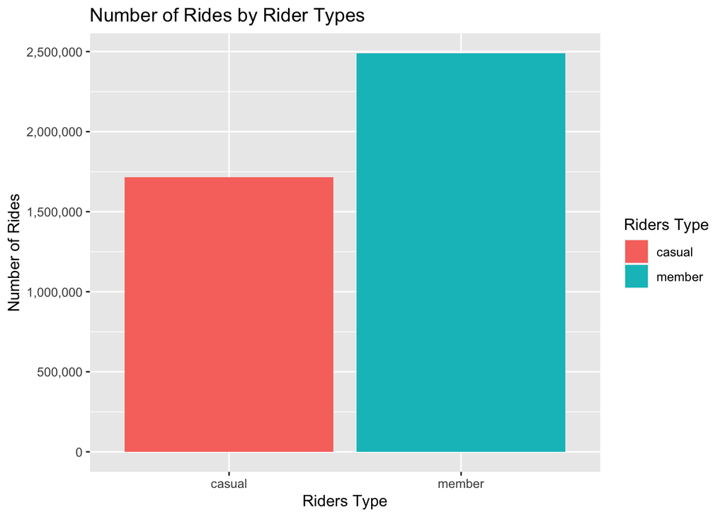

```r
all_trips_v3 %>%
  group_by(member_casual) %>%
  summarize(number_of_rides = n() , .groups = 'drop') %>%
  ggplot(aes(x = member_casual, y = number_of_rides, fill = member_casual)) +
  geom_col(position = "dodge") +
  labs(title = "Number of Rides by Rider Types", x = "Riders Type", y = "Number of Rides", fill = "Riders Type") +
  scale_y_continuous(labels = scales::comma)
```

Visualization of number of rides by days of week for riders type

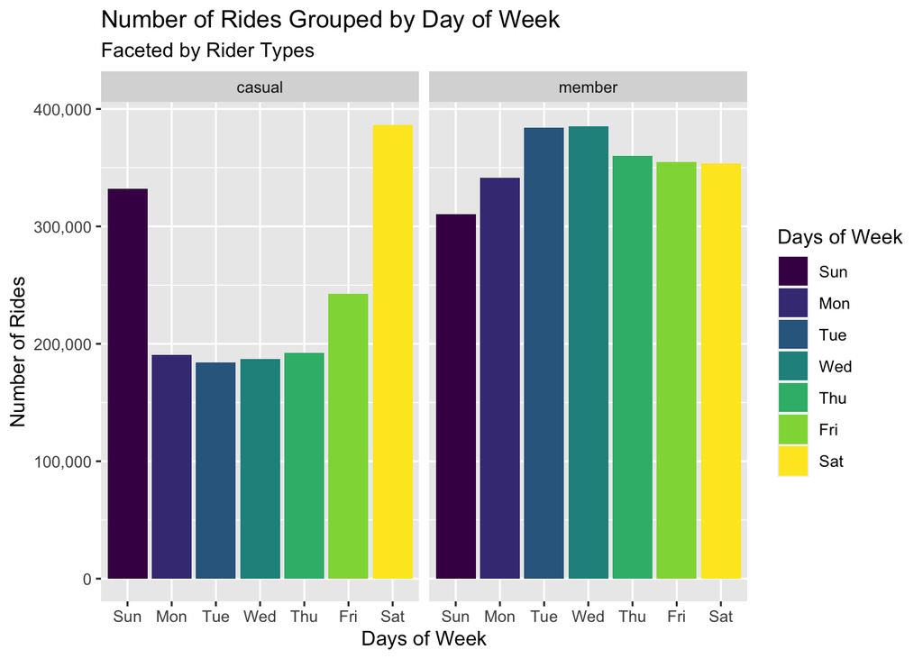

```r
all_trips_v3 %>%
  mutate(weekday = wday(started_at, label = TRUE)) %>%
  group_by(member_casual, weekday) %>%
  summarize(number_of_rides = n() , .groups = 'drop') %>%
  ggplot(aes(x = weekday, y = number_of_rides, fill = weekday)) +
  geom_col(position = "dodge") +
  facet_wrap(~ member_casual) +
  labs(title = "Number of Rides Grouped by Day of Week", subtitle = "Faceted by Rider Types", x = "Days of Week", y = "Number of Rides", fill = "Days of Week") +
  scale_y_continuous(labels = scales::comma)
```

Visualization of monthly number of rides by riders type

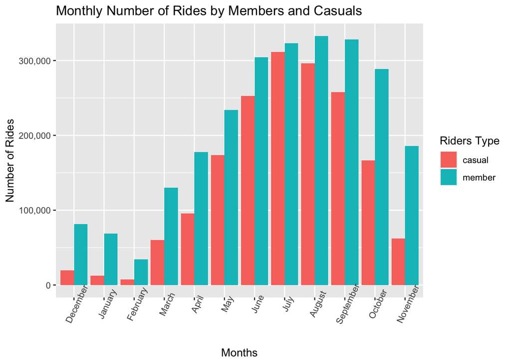

```r
all_trips_v3 %>%
  group_by(member_casual, month) %>%
  summarize(number_of_rides = n(), .groups = 'drop') %>%
  arrange(month) %>%
  ggplot(aes(x = month, y = number_of_rides, fill = member_casual)) +
  geom_bar(position = "dodge", stat = "identity") +
  theme(axis.text.x = element_text(angle = 65)) +
  labs(title = "Monthly Number of Rides by Members and Casuals",
       x = "Months", y = "Number of Rides", fill = "Riders Type") +
  scale_y_continuous(labels = scales::comma)
```

Visualization for number of rides by hours of the day for riders type

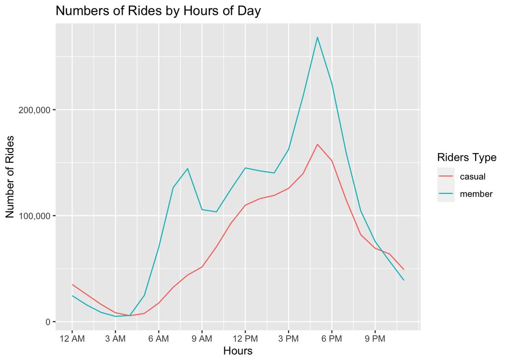

```r
all_trips_v3 %>%
  group_by(member_casual, hour) %>%
  summarize(number_of_rides = n(), .group = "drop") %>%
  ggplot(aes(x = hour, y = number_of_rides, color = member_casual)) +
  geom_line() +
  scale_x_time(breaks = c(0, 3, 6, 9, 12, 15, 18, 21),
               labels = c("12 AM", "3 AM", "6 AM", "9 AM", "12 PM", "3 PM", "6 PM", "9 PM")) +
  scale_y_continuous(labels = scales::comma) +
  labs(title = "Numbers of Rides by Hours of Day",
       x = "Hours", y = "Number of Rides", color = "Riders Type")
```

Visualization for average ride length per day by riders type

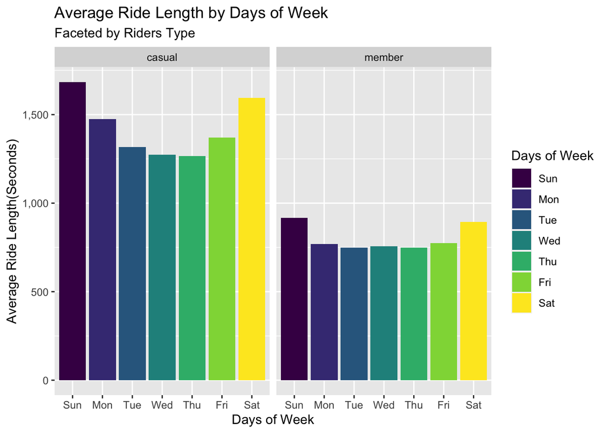

```r
all_trips_v3 %>%
  mutate(weekday = wday(started_at, label = TRUE)) %>%
  group_by(member_casual, weekday) %>%
  summarize(average_ride_length = mean(ride_length)) %>%
  arrange(member_casual, weekday) %>%
  ggplot(aes(x = weekday, y = average_ride_length, fill = weekday)) +
  geom_col(position = "dodge") +
  facet_wrap(~ member_casual) +
  labs(title = "Average Ride Length by Days of Week", subtitle = "Faceted by Riders Type",
       x = "Days of Week", y = "Average Ride Length(Seconds)", fill = "Days of Week") +
  scale_y_continuous(labels = scales::comma)
```

Visualization for average ride length per month by riders type

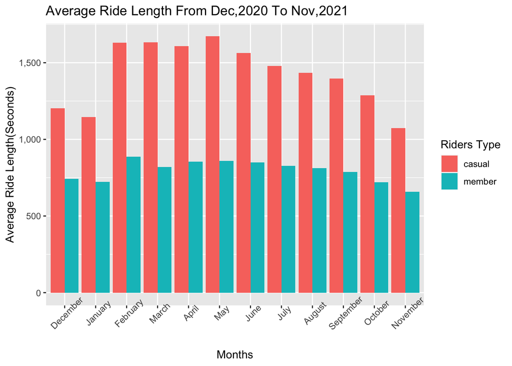

```r
all_trips_v3 %>%
  group_by(member_casual, month) %>%
  summarize(average_ride_length = mean(ride_length)) %>%
  arrange(member_casual, month) %>%
  ggplot(aes(x = month, y = average_ride_length, fill = member_casual)) +
  geom_col(position = "dodge") +
  theme(axis.text.x = element_text(angle = 45)) +
  labs(title = "Average Ride Length From Dec,2020 To Nov,2021", x = "Months",
       y = "Average Ride Length(Seconds)", fill = "Riders Type") +
  scale_y_continuous(labels = scales::comma)
```

Visualization for average ride length per hour by riders type

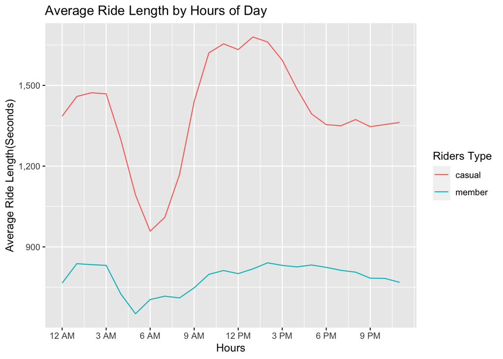

```r
all_trips_v3 %>%
  group_by(member_casual, hour) %>%
  summarize(average_ride_length = mean(ride_length)) %>%
  ggplot(aes(x = hour, y = average_ride_length, color = member_casual)) +
  geom_line() +
  scale_x_time(breaks = c(0, 3, 6, 9, 12, 15, 18, 21),
               labels = c("12 AM", "3 AM", "6 AM", "9 AM", "12 PM", "3 PM", "6 PM", "9 PM")) +
  scale_y_continuous(labels = scales::comma) +
  labs(title = "Average Ride Length by Hours of Day",
       x = "Hours", y = "Average Ride Length(Seconds)", color = "Riders Type")
```

### Analysis Findings

- From my analysis, it's clear that casual riders have less number of rides than members but their average ride length (duration in seconds) is comparatively more than members.
- From hourly data, we can say that casuals ride length has sharp rise around 7:30 AM till 10:00 AM while membership riders have almost constant average ride length.
- Another interesting finding is that casuals are more active at week end in compare to members who are using more bike rides on weekdays.

### Conclusion

- To attract casual users, short term membership over weekends can be good option.
- Membership discounts can also be planned for summer and autumn months (from May to October).